# Credit Scorecard Modelling

MATH 271.1: Statistical Methods

Jakov Ivan S. Dumbrique[^1]

October 29, 2021

## Load R packages and R scripts

`scorecardUtils.R` is an internal R script created by the instructor.

```r
library(MASS)
library(tidyverse)
library(scorecard)
library(readr)
source("scorecardUtils.R")

#setwd("~/Documents/5math271")
set.seed(314) # 1011
```

## Read csv files

The two csv files are the ones you produced under Sir Fadri’s class.

```r
germancredit_woe.dt <- read.csv("german_credit_woe_values2021.csv")
bins <- read.csv("germancredit_logical_bins_2021.csv", header = T)

germancredit_woe.dt %>%
  select(-X) %>%
  mutate(creditability = as.integer((creditability == "bad"))) ->
  germancredit_woe.dt

#germancredit_woe.dt %>%  View()
```

## Split the dataset into train and test sets

This should be done before binning. Using scorecard::split_df, the bad rate of the dataset is preserved across the train and test sets.

```r
dt_list <- split_df(germancredit_woe.dt, y="creditability", ratios = c(0.8, 0.2), seed = 314)
```

## Fit a Logistic Regression model using train set

```r
model1 <- glm(creditability ~ . ,
             family = binomial(link="logit"),
             data = dt_list$train)
#?glm
#model1
summary(model1)
```

```
Call:
glm(formula = creditability ~ ., family = binomial(link = "logit"),
    data = dt_list$train)

Deviance Residuals:
    Min       1Q   Median       3Q      Max
-2.1204  -0.6943  -0.3825   0.7347   2.5982

Coefficients: (1 not defined because of singularities)
                                                             Estimate Std. Error z value Pr(>|z|)
(Intercept)                                                  -0.84883    0.09392  -9.038  < 2e-16 ***
age.in.years_woe                                             -0.65154    0.31457  -2.071 0.038336 *
credit.amount_woe                                            -1.08919    0.29762  -3.660 0.000253 ***
credit.history_woe                                           -0.78541    0.18770  -4.184 2.86e-05 ***
duration.in.month_woe                                        -0.61572    0.20140  -3.057 0.002234 **
foreign.worker_woe                                                 NA         NA      NA       NA
housing_woe                                                  -0.57435    0.34693  -1.655 0.097824 .
installment.rate.in.percentage.of.disposable.income_woe      -2.08672    0.61153  -3.412 0.000644 ***
job_woe                                                       0.36827    1.18964   0.310 0.756892
number.of.existing.credits.at.this.bank_woe                   0.79983    0.99921   0.800 0.423442
number.of.people.being.liable.to.provide.maintenance.for_woe  7.31349   14.39251   0.508 0.611351
other.debtors.or.guarantors_woe                              -1.52751    0.78177  -1.954 0.050711 .
other.installment.plans_woe                                  -0.95304    0.37609  -2.534 0.011274 *
personal.status.and.sex_woe                                  -0.83481    0.96789  -0.863 0.388410
present.employment.since_woe                                 -0.89888    0.32731  -2.746 0.006028 **
present.residence.since_woe                                  -2.78000    1.52816  -1.819 0.068885 .
property_woe                                                 -0.31742    0.31925  -0.994 0.320091
purpose_woe                                                  -0.73791    0.24132  -3.058 0.002229 **
savings.account.and.bonds_woe                                -0.85423    0.22292  -3.832 0.000127 ***
status.of.existing.checking.account_woe                      -0.81410    0.11998  -6.785 1.16e-11 ***
telephone_woe                                                -0.95614    1.29061  -0.741 0.458788
---
Signif. codes:  0 ‘***’ 0.001 ‘**’ 0.01 ‘*’ 0.05 ‘.’ 0.1 ‘ ’ 1

(Dispersion parameter for binomial family taken to be 1)

    Null deviance: 990.41  on 815  degrees of freedom
Residual deviance: 737.46  on 796  degrees of freedom
AIC: 777.46

Number of Fisher Scoring iterations: 5
```

```r
aic <- model1$aic
```

## Evaluate model performance on test set

```r
y_pred <- predict(model1, dt_list$test, type="response")
```

```
prediction from a rank-deficient fit may be misleading
```

```
[INFO] The threshold of confusion matrix is 0.3433.
```

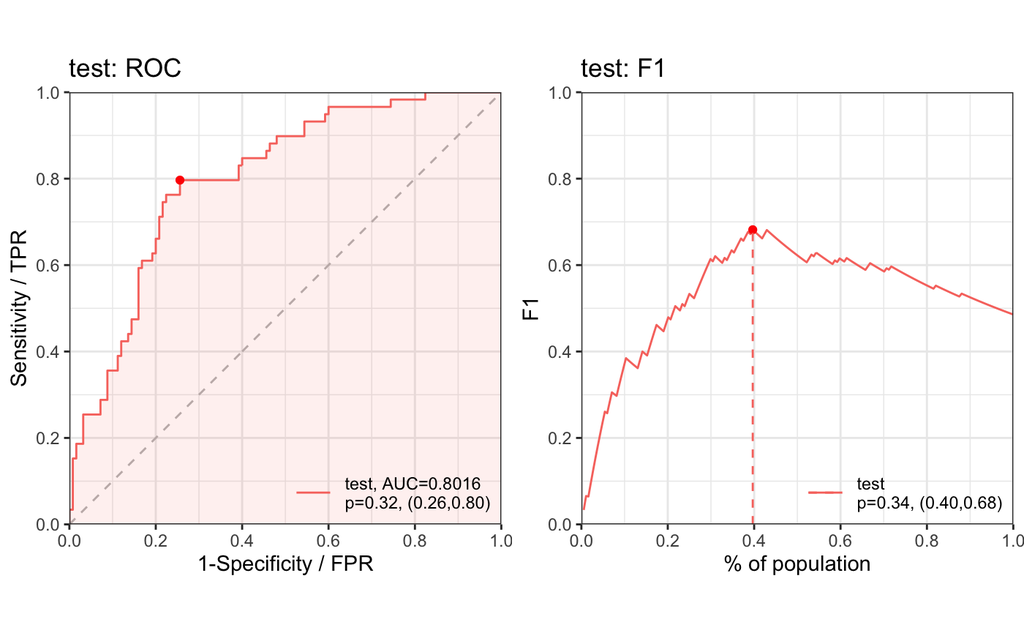

```r
metrics <- perf_eva(
  pred=y_pred,
  label=dt_list$test$creditability,
  title = 'test',
  binomial_metric = c("auc"),
  confusion_matrix = TRUE,
  show_plot = c('roc', 'f1')
  )
```

```r
metrics$confusion_matrix$test
```

| label | pred_0 | pred_1 | error |
| --- | --- | --- | --- |
| 0 | 97 | 28 | 0.2240000 |
| 1 | 14 | 45 | 0.2372881 |
| total | 111 | 73 | 0.2282609 |

```r
auc <- metrics$binomial_metric$test$AUC
```

Check the [`scorecard` documentation](https://cran.r-project.org/web/packages/scorecard/scorecard.pdf) for more details!

Because `scorecard::perf_eva` does not output the important evaluation metrics we discussed in class, the instructor created functions to do so:

1. `find_optimal_threshold` - mimics how scorecard::perf_eva finds the optimal threshold
2. `confusion_matrix` - generates the confusion matrix at a certain threshold
3. `get_metrics` - calculates the accuracy, precision, sensitivity, specificity, and F1 score at a given threshold

```r
# these are functions that you might want to implement for your Project.
threshold <- find_optimal_threshold(
  pred=y_pred,
  label=dt_list$test$creditability
  )

#threshold

confusion_matrix(pred=y_pred,
                   label=dt_list$test$creditability,
                   threshold=threshold)
```

|  | pred_0 | pred_1 |
| --- | --- | --- |
| actual_0 | 97 | 28 |
| actual_1 | 14 | 45 |

```r
metrics_model1 <- get_metrics(pred=y_pred,
                   label=dt_list$test$creditability,
                   threshold=threshold)

metrics_model1 %>%
  add_row(metrics='auc', values=auc) %>%
  add_row(metrics='aic', values=aic) ->
  metrics_model1

metrics_model1
```

| metrics | values |
| --- | --- |
| threshold | 0.3432500 |
| accuracy | 0.7717391 |
| precision | 0.6164384 |
| sensitivity | 0.7627119 |
| specificity | 0.7760000 |
| f1 | 0.6818182 |
| auc | 0.8016271 |
| aic | 777.4583261 |

### Other valuation metrics

1. Somer’s D
   - use the `InformationValue::somersD()` function
2. Kolmogorov-Smirnov (KS) Statistic
   - You can use this as an alternative to find the optimal threshold (cut-off probability)
   - specify ‘ks’ in the `binomial_metric` parameter of the `scorecard::perf_eva()` function
3. Cumulative Accuracy Profile (CAP) and Gini Coefficient
   - specify ‘gini’ in the `binomial_metric` parameter of the `scorecard::perf_eva()` function

**Goodness-of-Fit Statistical Test**

1. Hosmer-Lemeshow Test
   - use the `ResourceSelection::hoslem.test()` function

## Variable Selection

This is a creative process. Don’t be afraid to experiment! Remember, you are looking for the best subset out of the 2^20 (over a million) total subsets!

A typical starting point for the set of experiments would be:

1. model1 - full model that uses all the 20 variables
2. model2 - result of forward selection
3. model3 - result of backward selection
4. model4 - result of stepwise selection

Other procedures you should try:

- removing multicollinear variables (assessed through VIF)
- removing variables with illogical parameter estimates ($\beta_m$ is positive)
- using only the significant variables at a certain level of confidence (p-values are calculated in summary(model))
- filtering the variables according to their information values

```r
null_model <- glm(creditability ~ 1,
                  family = binomial(link="logit"),
                  data = dt_list$train
                  )
```

model2 - result of forward selection

```r
model2 <- step(null_model,
               direction = 'forward',
               trace = FALSE, #if TRUE, then it will give you the step-by-step output
               k = 2, #2 -> AIC
               scope = list(upper=model1)
              )

summary(model2)
```

```
Call:
glm(formula = creditability ~ status.of.existing.checking.account_woe +
    duration.in.month_woe + credit.history_woe + savings.account.and.bonds_woe +
    purpose_woe + credit.amount_woe + installment.rate.in.percentage.of.disposable.income_woe +
    present.employment.since_woe + housing_woe + other.installment.plans_woe +
    age.in.years_woe + other.debtors.or.guarantors_woe + present.residence.since_woe,
    family = binomial(link = "logit"), data = dt_list$train)

Deviance Residuals:
    Min       1Q   Median       3Q      Max
-2.1396  -0.7068  -0.3792   0.7529   2.6355

Coefficients:
                                                        Estimate Std. Error z value Pr(>|z|)
(Intercept)                                             -0.85746    0.09341  -9.180  < 2e-16 ***
status.of.existing.checking.account_woe                 -0.81692    0.11898  -6.866 6.59e-12 ***
duration.in.month_woe                                   -0.63594    0.19908  -3.194 0.001401 **
credit.history_woe                                      -0.75705    0.17698  -4.278 1.89e-05 ***
savings.account.and.bonds_woe                           -0.85907    0.22070  -3.893 9.92e-05 ***
purpose_woe                                             -0.75822    0.23901  -3.172 0.001512 **
credit.amount_woe                                       -1.05847    0.27262  -3.883 0.000103 ***
installment.rate.in.percentage.of.disposable.income_woe -2.10437    0.60165  -3.498 0.000469 ***
present.employment.since_woe                            -0.87090    0.32473  -2.682 0.007320 **
housing_woe                                             -0.68841    0.31841  -2.162 0.030619 *
other.installment.plans_woe                             -0.99365    0.37114  -2.677 0.007422 **
age.in.years_woe                                        -0.59819    0.29421  -2.033 0.042034 *
other.debtors.or.guarantors_woe                         -1.54888    0.76817  -2.016 0.043766 *
present.residence.since_woe                             -2.81691    1.51980  -1.853 0.063814 .
---
Signif. codes:  0 ‘***’ 0.001 ‘**’ 0.01 ‘*’ 0.05 ‘.’ 0.1 ‘ ’ 1

(Dispersion parameter for binomial family taken to be 1)

    Null deviance: 990.41  on 815  degrees of freedom
Residual deviance: 741.01  on 802  degrees of freedom
AIC: 769.01

Number of Fisher Scoring iterations: 5
```

model3 - result of backward selection

```r
model3 <- step(model1,
               direction = 'backward',
               trace = FALSE,
               k = 2,
              )

summary(model3)
```

```
Call:
glm(formula = creditability ~ age.in.years_woe + credit.amount_woe +
    credit.history_woe + duration.in.month_woe + housing_woe +
    installment.rate.in.percentage.of.disposable.income_woe +
    other.debtors.or.guarantors_woe + other.installment.plans_woe +
    present.employment.since_woe + present.residence.since_woe +
    purpose_woe + savings.account.and.bonds_woe + status.of.existing.checking.account_woe,
    family = binomial(link = "logit"), data = dt_list$train)

Deviance Residuals:
    Min       1Q   Median       3Q      Max
-2.1396  -0.7068  -0.3792   0.7529   2.6355

Coefficients:
                                                        Estimate Std. Error z value Pr(>|z|)
(Intercept)                                             -0.85746    0.09341  -9.180  < 2e-16 ***
age.in.years_woe                                        -0.59819    0.29421  -2.033 0.042034 *
credit.amount_woe                                       -1.05847    0.27262  -3.883 0.000103 ***
credit.history_woe                                      -0.75705    0.17698  -4.278 1.89e-05 ***
duration.in.month_woe                                   -0.63594    0.19908  -3.194 0.001401 **
housing_woe                                             -0.68841    0.31841  -2.162 0.030619 *
installment.rate.in.percentage.of.disposable.income_woe -2.10437    0.60165  -3.498 0.000469 ***
other.debtors.or.guarantors_woe                         -1.54888    0.76817  -2.016 0.043766 *
other.installment.plans_woe                             -0.99365    0.37114  -2.677 0.007422 **
present.employment.since_woe                            -0.87090    0.32473  -2.682 0.007320 **
present.residence.since_woe                             -2.81691    1.51980  -1.853 0.063814 .
purpose_woe                                             -0.75822    0.23901  -3.172 0.001512 **
savings.account.and.bonds_woe                           -0.85907    0.22070  -3.893 9.92e-05 ***
status.of.existing.checking.account_woe                 -0.81692    0.11898  -6.866 6.59e-12 ***
---
Signif. codes:  0 ‘***’ 0.001 ‘**’ 0.01 ‘*’ 0.05 ‘.’ 0.1 ‘ ’ 1

(Dispersion parameter for binomial family taken to be 1)

    Null deviance: 990.41  on 815  degrees of freedom
Residual deviance: 741.01  on 802  degrees of freedom
AIC: 769.01

Number of Fisher Scoring iterations: 5
```

model4 - result of stepwise selection

```r
model4 <- step(null_model,
               direction = 'both',
               trace = FALSE,
               k = 2,
               scope = list(upper=model1)
              )

summary(model4)
```

```
Call:
glm(formula = creditability ~ status.of.existing.checking.account_woe +
    duration.in.month_woe + credit.history_woe + savings.account.and.bonds_woe +
    purpose_woe + credit.amount_woe + installment.rate.in.percentage.of.disposable.income_woe +
    present.employment.since_woe + housing_woe + other.installment.plans_woe +
    age.in.years_woe + other.debtors.or.guarantors_woe + present.residence.since_woe,
    family = binomial(link = "logit"), data = dt_list$train)

Deviance Residuals:
    Min       1Q   Median       3Q      Max
-2.1396  -0.7068  -0.3792   0.7529   2.6355

Coefficients:
                                                        Estimate Std. Error z value Pr(>|z|)
(Intercept)                                             -0.85746    0.09341  -9.180  < 2e-16 ***
status.of.existing.checking.account_woe                 -0.81692    0.11898  -6.866 6.59e-12 ***
duration.in.month_woe                                   -0.63594    0.19908  -3.194 0.001401 **
credit.history_woe                                      -0.75705    0.17698  -4.278 1.89e-05 ***
savings.account.and.bonds_woe                           -0.85907    0.22070  -3.893 9.92e-05 ***
purpose_woe                                             -0.75822    0.23901  -3.172 0.001512 **
credit.amount_woe                                       -1.05847    0.27262  -3.883 0.000103 ***
installment.rate.in.percentage.of.disposable.income_woe -2.10437    0.60165  -3.498 0.000469 ***
present.employment.since_woe                            -0.87090    0.32473  -2.682 0.007320 **
housing_woe                                             -0.68841    0.31841  -2.162 0.030619 *
other.installment.plans_woe                             -0.99365    0.37114  -2.677 0.007422 **
age.in.years_woe                                        -0.59819    0.29421  -2.033 0.042034 *
other.debtors.or.guarantors_woe                         -1.54888    0.76817  -2.016 0.043766 *
present.residence.since_woe                             -2.81691    1.51980  -1.853 0.063814 .
---
Signif. codes:  0 ‘***’ 0.001 ‘**’ 0.01 ‘*’ 0.05 ‘.’ 0.1 ‘ ’ 1

(Dispersion parameter for binomial family taken to be 1)

    Null deviance: 990.41  on 815  degrees of freedom
Residual deviance: 741.01  on 802  degrees of freedom
AIC: 769.01

Number of Fisher Scoring iterations: 5
```

It seems like all three selection procedures produced the same model. You can verify this by checking if the models used the same subset of variables.

```r
identical(model2$coefficients %>% names() %>% sort(),
          model3$coefficients %>% names() %>% sort())
```

```
[1] TRUE
```

```r
identical(model2$coefficients %>% names() %>% sort(),
          model4$coefficients %>% names() %>% sort())
```

```
[1] TRUE
```

## Evaluate the candidate models

```r
evaluate_model <- function(model, dt_list){
  aic <- model$aic
  y_pred <- predict(model, dt_list$test, type="response")

  metrics <- perf_eva(
    pred=y_pred,
    label=dt_list$test$creditability,
    title = 'test',
    binomial_metric = c("auc"),
    confusion_matrix = TRUE,
    show_plot = c('roc', 'f1')
    )

  auc <- metrics$binomial_metric$test$AUC

  threshold <- find_optimal_threshold(
                pred=y_pred,
                label=dt_list$test$creditability
                )

  metrics_dt <- get_metrics(pred=y_pred,
                     label=dt_list$test$creditability,
                     threshold=threshold)

  metrics_dt %>%
    add_row(metrics='auc', values=auc) %>%
    add_row(metrics='aic', values=aic) ->
    metrics_dt

  return(metrics_dt)
}
```

```r
metrics_model1
```

| metrics | values |
| --- | --- |
| threshold | 0.3432500 |
| accuracy | 0.7717391 |
| precision | 0.6164384 |
| sensitivity | 0.7627119 |
| specificity | 0.7760000 |
| f1 | 0.6818182 |
| auc | 0.8016271 |
| aic | 777.4583261 |

```
[INFO] The threshold of confusion matrix is 0.3344.
```

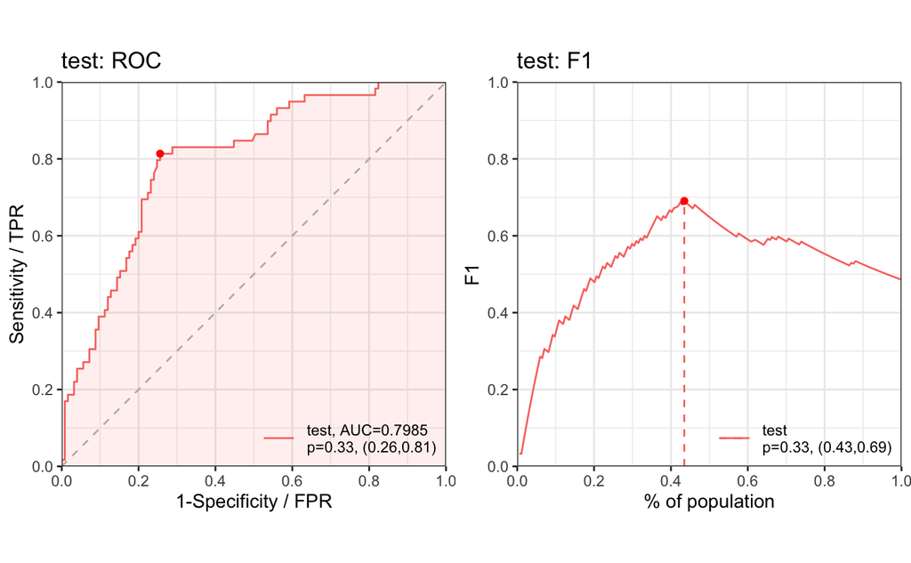

```r
metrics_model2 <- evaluate_model(model2, dt_list)
```

```r
metrics_model2
```

| metrics | values |
| --- | --- |
| threshold | 0.3343500 |
| accuracy | 0.7663043 |
| precision | 0.6000000 |
| sensitivity | 0.8135593 |
| specificity | 0.7440000 |
| f1 | 0.6906475 |
| auc | 0.7985085 |
| aic | 769.0086220 |

model2 achieved a higher sensitivity, higher f1 score, and lower aic.

## Testing for Multicollinearity

```r
#vif(model1)

vif(model2)
```

| variable | gvif |
| --- | --- |
| status.of.existing.checking.account_woe | 1.049998 |
| duration.in.month_woe | 1.231992 |
| credit.history_woe | 1.043186 |
| savings.account.and.bonds_woe | 1.051614 |
| purpose_woe | 1.038299 |
| credit.amount_woe | 1.338523 |
| installment.rate.in.percentage.of.disposable.income_woe | 1.129142 |
| present.employment.since_woe | 1.085970 |
| housing_woe | 1.024855 |
| other.installment.plans_woe | 1.048900 |

[output cut: 3 more lines]

If you run `vif(model1)`, you would get an error `There are aliased coefficients in the model`. This error arises if there is perfect multicollinearity in the subset of variables. That is, there is at least one variable that is linearly dependent on the other variables. Upon inspection of the coefficients in model1, you can tell that the variable of concern is `foreign.worker_woe`. This is because there is only one bin for this variable, as seen below. Thus, `foreign.worker_woe`=0, and it could be expressed as a linear combination of the other variables. To mitigate this, you can try rebinning the foreign.worker variable to have two bins:(1)if the applicant is a foreign worker and (2) if he/she is not.

```r
bins %>%
  filter(variable =="foreign.worker")
```

| X | variable | bin | count | count_distr | neg | pos | posprob | woe | bin_iv | total_iv | breaks | is_special_values |
| --- | --- | --- | --- | --- | --- | --- | --- | --- | --- | --- | --- | --- |
| 17 | foreign.worker | yes%,%no | 1000 | 1 | 700 | 300 | 0.3 | 0 | 0 | 0 | yes%,%no | FALSE |

Looking at the vif of the variables in model2, all the vifs are close to 1. Thus, there is no multicollinearity for the subset of variables used for model2.

## Using the significant variables at a given level of confidence

model5 - include only the significant variables from model1 ($\alpha=0.10$).

```r
summary(model1)
```

```
Call:
glm(formula = creditability ~ ., family = binomial(link = "logit"),
    data = dt_list$train)

Deviance Residuals:
    Min       1Q   Median       3Q      Max
-2.1204  -0.6943  -0.3825   0.7347   2.5982

Coefficients: (1 not defined because of singularities)
                                                             Estimate Std. Error z value Pr(>|z|)
(Intercept)                                                  -0.84883    0.09392  -9.038  < 2e-16 ***
age.in.years_woe                                             -0.65154    0.31457  -2.071 0.038336 *
credit.amount_woe                                            -1.08919    0.29762  -3.660 0.000253 ***
credit.history_woe                                           -0.78541    0.18770  -4.184 2.86e-05 ***
duration.in.month_woe                                        -0.61572    0.20140  -3.057 0.002234 **
foreign.worker_woe                                                 NA         NA      NA       NA
housing_woe                                                  -0.57435    0.34693  -1.655 0.097824 .
installment.rate.in.percentage.of.disposable.income_woe      -2.08672    0.61153  -3.412 0.000644 ***
job_woe                                                       0.36827    1.18964   0.310 0.756892
number.of.existing.credits.at.this.bank_woe                   0.79983    0.99921   0.800 0.423442
number.of.people.being.liable.to.provide.maintenance.for_woe  7.31349   14.39251   0.508 0.611351
other.debtors.or.guarantors_woe                              -1.52751    0.78177  -1.954 0.050711 .
other.installment.plans_woe                                  -0.95304    0.37609  -2.534 0.011274 *
personal.status.and.sex_woe                                  -0.83481    0.96789  -0.863 0.388410
present.employment.since_woe                                 -0.89888    0.32731  -2.746 0.006028 **
present.residence.since_woe                                  -2.78000    1.52816  -1.819 0.068885 .
property_woe                                                 -0.31742    0.31925  -0.994 0.320091
purpose_woe                                                  -0.73791    0.24132  -3.058 0.002229 **
savings.account.and.bonds_woe                                -0.85423    0.22292  -3.832 0.000127 ***
status.of.existing.checking.account_woe                      -0.81410    0.11998  -6.785 1.16e-11 ***
telephone_woe                                                -0.95614    1.29061  -0.741 0.458788
---
Signif. codes:  0 ‘***’ 0.001 ‘**’ 0.01 ‘*’ 0.05 ‘.’ 0.1 ‘ ’ 1

(Dispersion parameter for binomial family taken to be 1)

    Null deviance: 990.41  on 815  degrees of freedom
Residual deviance: 737.46  on 796  degrees of freedom
AIC: 777.46

Number of Fisher Scoring iterations: 5
```

```r
(summary(model1)$coefficients[, "Pr(>|z|)"] < 0.10) %>%
  names(.)[.] %>% # get the names of the variables that satisfied the equation
  .[-1] %>%  # remove "(Intercept)"
  c("creditability",.) -> # add "creditability"
  model5_varnames

model5_varnames
```

```
 [1] "creditability"                                           "age.in.years_woe"
 [3] "credit.amount_woe"                                       "credit.history_woe"
 [5] "duration.in.month_woe"                                   "housing_woe"
 [7] "installment.rate.in.percentage.of.disposable.income_woe" "other.debtors.or.guarantors_woe"
 [9] "other.installment.plans_woe"                             "present.employment.since_woe"
[11] "present.residence.since_woe"                             "purpose_woe"
[13] "savings.account.and.bonds_woe"                           "status.of.existing.checking.account_woe"
```

```r
col_ind =c(which((names(dt_list$train) %in% model5_varnames)==TRUE))
dt_list$train[,..col_ind]
```

[output not shown]

[output cut: 806 more lines]

```r
model5 <- glm(creditability ~ .,
                  family = binomial(link="logit"),
                  data = dt_list$train[,..col_ind]
                  )

summary(model5)
```

```
Call:
glm(formula = creditability ~ ., family = binomial(link = "logit"),
    data = dt_list$train[, ..col_ind])

Deviance Residuals:
    Min       1Q   Median       3Q      Max
-2.1396  -0.7068  -0.3792   0.7529   2.6355

Coefficients:
                                                        Estimate Std. Error z value Pr(>|z|)
(Intercept)                                             -0.85746    0.09341  -9.180  < 2e-16 ***
age.in.years_woe                                        -0.59819    0.29421  -2.033 0.042034 *
credit.amount_woe                                       -1.05847    0.27262  -3.883 0.000103 ***
credit.history_woe                                      -0.75705    0.17698  -4.278 1.89e-05 ***
duration.in.month_woe                                   -0.63594    0.19908  -3.194 0.001401 **
housing_woe                                             -0.68841    0.31841  -2.162 0.030619 *
installment.rate.in.percentage.of.disposable.income_woe -2.10437    0.60165  -3.498 0.000469 ***
other.debtors.or.guarantors_woe                         -1.54888    0.76817  -2.016 0.043766 *
other.installment.plans_woe                             -0.99365    0.37114  -2.677 0.007422 **
present.employment.since_woe                            -0.87090    0.32473  -2.682 0.007320 **
present.residence.since_woe                             -2.81691    1.51980  -1.853 0.063814 .
purpose_woe                                             -0.75822    0.23901  -3.172 0.001512 **
savings.account.and.bonds_woe                           -0.85907    0.22070  -3.893 9.92e-05 ***
status.of.existing.checking.account_woe                 -0.81692    0.11898  -6.866 6.59e-12 ***
---
Signif. codes:  0 ‘***’ 0.001 ‘**’ 0.01 ‘*’ 0.05 ‘.’ 0.1 ‘ ’ 1

(Dispersion parameter for binomial family taken to be 1)

    Null deviance: 990.41  on 815  degrees of freedom
Residual deviance: 741.01  on 802  degrees of freedom
AIC: 769.01

Number of Fisher Scoring iterations: 5
```

It turns out that model5 is the same as model2!

```r
identical(model2$coefficients %>% names() %>% sort(),
          model5$coefficients %>% names() %>% sort())
```

```
[1] TRUE
```

## Scorecard development

Once you have chosen already the best candidate model, you can now transform it into a scorecard format.

```r
card <- scorecard(bins,
          model2,
          points0 = 600, # points at the specified odds
          odds0 = 1/50, # this is the bad/good odds
          pdo = 20, # points needed to double the odds
          )
```

## Using the scorecard in production

```r
scorecard_ply(germancredit, card) %>% View()
```

## Calculate the cutoff score

`cutoff_score` is an internal R function created by the instructor. Given the optimal threshold, it calculates the corresponding cut-off score for the scorecard.

```r
metrics_model2 %>%
  filter(metrics=="threshold") %>%
  select(values) ->
  threshold
```

```r
# these is a function that you might want to implement for your Project.
cutoff_score <- get_cutoff_score(threshold=threshold,
                 points0=600,
                 odds0=1/50,
                 pdo=20)
cutoff_score
```

| values |
| --- |
| 506.991 |

## Saving the scorecard

```r
card$basepoints$variable <- "[base points]"
card_list <- lapply(card, function(x) x %>%
                      select(variable, bin, points))
Reduce(function(x, y) merge(x, y, all=TRUE), card_list) %>%
  write.csv("scorecard_model2.csv", row.names=FALSE)

#Reduce(function(x, y) merge(x, y, all=TRUE), card_list) %>%  View()
```

[^1]: Ateneo de Manila University, jdumbrique@ateneo.edu